# Severe Weather Analysis: What is the most devastating storm?

#### Synopsis

The purpose of this analysis is to answer two questions:

- Across the United States, which types of events are most harmful with respect to population health?
- Across the United States, which types of events have the greatest economic consequences?

The data used were provided by the National Oceanic and Atmospheric Administration (NOAA), and consisted of logged sever weather events dating from 1950 to 2011. The logged data contained the following variables that were used during the analysis:

- EVTYPE: Event type
- PROPDMG: Property Damage in dollars
- PROPDMGEXP: Property Damage multiplier (K = thousand, M = million, B = billion)
- CROPDMG: Crop Damage in dollars
- CROPDMGEXP: Crop Damage multiplier (K = thousand, M= million, B = billion)
- FATALITIES: Deaths caused by the incident
- INJURIES: Injuries caused by the incident

The data was then transformed by multiplying the damage variables by their multipliers. Two new variables were engineered:

- DAMAGE: Total damage in dollars. Property damage was weighted by 3 against crop damage to account for the additional strain on the economy felt by property damage
- CASUALTIES: Total injuries and deaths caused by the event. Deaths are weighted by 15 against injuries.

The analysis concluded the following:

- Tornados accounted for the most total casualties
- Floods accounted for the most total damage
- On average, hurricanes caused the most damage + On average, tsunamis caused the most casualties
- On average, hurricanes are the most devastating storm.

#### Data Processing

We want R to do the heavy lifting, so we have it download the data. We read in the csv and take a look.

```r
download.file("https://d396qusza40orc.cloudfront.net/repdata%2Fdata%2FStormData.csv.bz2", "storm_data.csv")
df <- read.csv("storm_data.csv")

summary(df)
```

```
##     STATE__       BGN_DATE           BGN_TIME          TIME_ZONE
##  Min.   : 1.0   Length:902297      Length:902297      Length:902297
##  1st Qu.:19.0   Class :character   Class :character   Class :character
##  Median :30.0   Mode  :character   Mode  :character   Mode  :character
##  Mean   :31.2
##  3rd Qu.:45.0
##  Max.   :95.0
##
##      COUNTY       COUNTYNAME           STATE              EVTYPE
##  Min.   :  0.0   Length:902297      Length:902297      Length:902297
##  1st Qu.: 31.0   Class :character   Class :character   Class :character
##  Median : 75.0   Mode  :character   Mode  :character   Mode  :character
##  Mean   :100.6
##  3rd Qu.:131.0
##  Max.   :873.0
##
##    BGN_RANGE          BGN_AZI           BGN_LOCATI          END_DATE
##  Min.   :   0.000   Length:902297      Length:902297      Length:902297
##  1st Qu.:   0.000   Class :character   Class :character   Class :character
##  Median :   0.000   Mode  :character   Mode  :character   Mode  :character
##  Mean   :   1.484
##  3rd Qu.:   1.000
##  Max.   :3749.000
##
##    END_TIME           COUNTY_END COUNTYENDN       END_RANGE
##  Length:902297      Min.   :0    Mode:logical   Min.   :  0.0000
##  Class :character   1st Qu.:0    NA's:902297    1st Qu.:  0.0000
##  Mode  :character   Median :0                   Median :  0.0000
##                     Mean   :0                   Mean   :  0.9862
##                     3rd Qu.:0                   3rd Qu.:  0.0000
##                     Max.   :0                   Max.   :925.0000
##
##    END_AZI           END_LOCATI            LENGTH              WIDTH
##  Length:902297      Length:902297      Min.   :   0.0000   Min.   :   0.000
##  Class :character   Class :character   1st Qu.:   0.0000   1st Qu.:   0.000
##  Mode  :character   Mode  :character   Median :   0.0000   Median :   0.000
##                                        Mean   :   0.2301   Mean   :   7.503
##                                        3rd Qu.:   0.0000   3rd Qu.:   0.000
##                                        Max.   :2315.0000   Max.   :4400.000
##
```

[output cut: 25 more lines]

```
##  Min.   :-14451   Min.   :   0   Min.   :-14455   Length:902297
##  1st Qu.:  7247   1st Qu.:   0   1st Qu.:     0   Class :character
##  Median :  8707   Median :   0   Median :     0   Mode  :character
##  Mean   :  6940   Mean   :1452   Mean   :  3509
##  3rd Qu.:  9605   3rd Qu.:3549   3rd Qu.:  8735
##  Max.   : 17124   Max.   :9706   Max.   :106220
##                   NA's   :40
##      REFNUM
##  Min.   :     1
##  1st Qu.:225575
##  Median :451149
##  Mean   :451149
##  3rd Qu.:676723
##  Max.   :902297
##
```

There’s quite a bit of work to be done here. In an ideal world, we would know exactly what we have to do so when we load in the data we can set our variable types. We can do this manually now.

Let’s make a copy of the df to manipulate, and subset on the columns that will be used during analysis.

```r
library(dplyr)
w_df <- df
w_df <- select(w_df, c("BGN_DATE", "STATE", "EVTYPE", "F", "MAG", "FATALITIES", "INJURIES", "PROPDMG", "PROPDMGEXP", "CROPDMG", "CROPDMGEXP", "LATITUDE", "LONGITUDE"))
```

Let’s start by processing the datetime. For our questions, just the date should be okay, we don’t need the time or timezone.

```r
library(tidyr)
library(lubridate)
w_df <-
        w_df %>%
                separate(BGN_DATE, c("BGN_DATE", "drop_me"), " ")

w_df$BGN_DATE <- mdy(w_df$BGN_DATE)

w_df <- select(w_df, -c("drop_me"))
```

```r
#Fuzzy Matching library
library(stringdist)
```

```r
#Dictionary of approved events
dictionary <- c("Astronomical Low Tide","Avalanche","Blizzard","Coastal Flood","Cold/Wind Chill","Debris Flow","Dense Fog","Dense Smoke","Drought","Dust Devil","Dust Storm","Excessive Heat","Extreme Cold/Wind Chill","Flash Flood","Flood","Freezing Fog","Frost/Freeze","Funnel Cloud","Hail","Heat","Heavy Rain","Heavy Snow","High Surf","High Wind","Hurricane/Typhoon","Ice Storm","Lakeshore Flood","Lake-Effect Snow","Lightning","Marine Hail","Marine High Wind","Marine Strong Wind","Marine Thunderstorm Wind","Rip Current","Seiche","Sleet","Storm Tide","Strong Wind","Thunderstorm Wind","Tornado","Tropical Depression","Tropical Storm","Tsunami","Volcanic Ash","Waterspout","Wildfire","Winter Storm","Winter Weather")

#Making everything uppercase to facilitate matching
dictionary <- toupper(dictionary)
w_df$EVTYPE <- toupper(w_df$EVTYPE)

#Fuzzy matching using Jaro-Winkler Distance
w_df$EVENT <- dictionary[amatch(w_df$EVTYPE, dictionary, method = "dl", maxDist = 20)]
w_df$EVENT <- as.factor(w_df$EVENT)
```

PROPDMGEXP and CROPDMGEXP is the multiplier for property damage, so we need to standardize it. First let’s explore how much garbarge is in the dataset.

```r
unique(w_df$PROPDMGEXP)
```

```
##  [1] "K" "M" ""  "B" "m" "+" "0" "5" "6" "?" "4" "2" "3" "h" "7" "H" "-" "1" "8"
```

```r
unique(w_df$CROPDMGEXP)
```

```
## [1] ""  "M" "K" "m" "B" "?" "0" "k" "2"
```

```r
n_df <- w_df[w_df$PROPDMGEXP %in% c("K", "M", "B", ""), ]

numrows_bad <- nrow((w_df[!w_df$PROPDMGEXP %in% c("K", "M", "B", ""), ]))

numrows_good <- nrow(n_df)

numrows_bad / numrows_good
```

```
## [1] 0.0003636489
```

An exceptionally small percentage of our observations have garbage in them, so I think we can drop them without any issues, and then replace the blank rows with “K”, since it doesn’t really matter, as if the cell is blank, the value is 0, then the process will be repeated for the CROPDMGEXP variable.

```r
n_df$PROPDMGEXP <- sub("^$", "K", n_df$PROPDMGEXP)

c_df <- n_df[n_df$CROPDMGEXP %in% c("K", "M", "B", ""), ]
c_df$CROPDMGEXP <- sub("^$", "K", c_df$CROPDMGEXP)
```

Now let’s calculate the actual dollar values for damage instead of the weird damage number.

```r
c_df$CROPDMGEXP <- sub("K", 1000, c_df$CROPDMGEXP)
c_df$CROPDMGEXP <- sub("M", 1000000, c_df$CROPDMGEXP)
c_df$CROPDMGEXP <- sub("B", 1000000000, c_df$CROPDMGEXP)

c_df$PROPDMGEXP <- sub("K", 1000, c_df$PROPDMGEXP)
c_df$PROPDMGEXP <- sub("M", 1000000, c_df$PROPDMGEXP)
c_df$PROPDMGEXP <- sub("B", 1000000000, c_df$PROPDMGEXP)

c_df$PROPDMGEXP <- as.numeric(c_df$PROPDMGEXP)
c_df$CROPDMGEXP <- as.numeric(c_df$CROPDMGEXP)

c_df$PROPDMG <- c_df$PROPDMG * c_df$PROPDMGEXP
c_df$CROPDMG <- c_df$CROPDMG * c_df$CROPDMGEXP

c_df <- select(c_df, -c("PROPDMGEXP", "CROPDMGEXP"))
```

And now we get to have a philosophical discussion regarding what “population health” and “economic consequences” are.

1. Population Health: From our dataset, this has to be a function of injuries and fatalities. Deaths are worse by most measures, but they don’t put additional strain on hospital resources. For our measurement, a death will be 15 times worse than an injury.
2. Economic Consequences: From our dataset, economic consequences has to be a function of property damage and crop damage. While crop damage can damage the economy, displaced workers and a rapid increase in the homeless population is worse. For our measurement, a dollar of property damage will be 3 times worse than a dollar of crop damage.

```r
c_df$DAMAGE <- (c_df$PROPDMG * 3) + (c_df$CROPDMG)
c_df$CASUALTIES <- (c_df$FATALITIES * 15) + (c_df$INJURIES)
master <- c_df
```

#### Results

##### Across the United States, which types of events (as indicated in the EVTYPE variable) are most harmful with respect to population health?

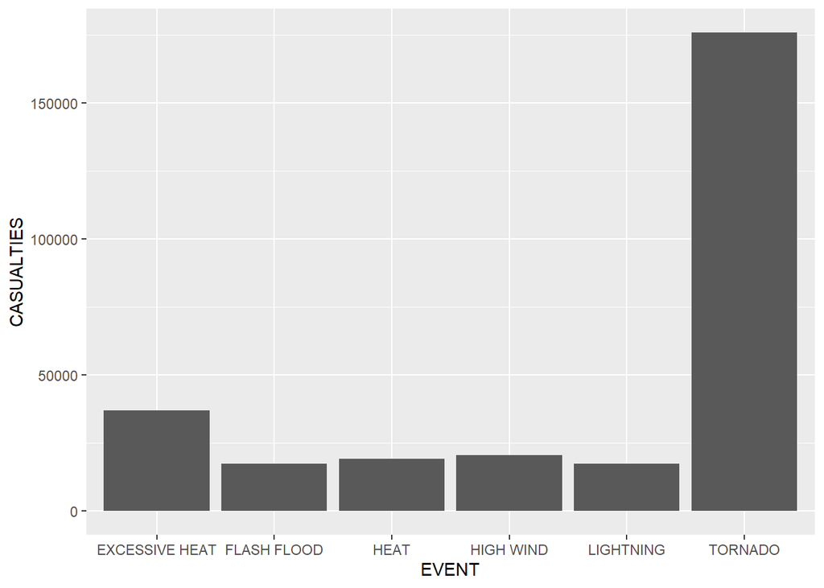

```r
library(ggplot2)

sum_df_casualities <- aggregate(CASUALTIES ~ EVENT, data = master,  FUN = sum)
sum_df_casualities <- sum_df_casualities[order(-sum_df_casualities$CASUALTIES), ]

ggplot(data = head(sum_df_casualities), mapping = aes(x = EVENT, y = CASUALTIES)) + geom_col()
```

Tornado’s are by far the most impactful on population heath.

##### Across the United States, which types of events have the greatest economic consequences?

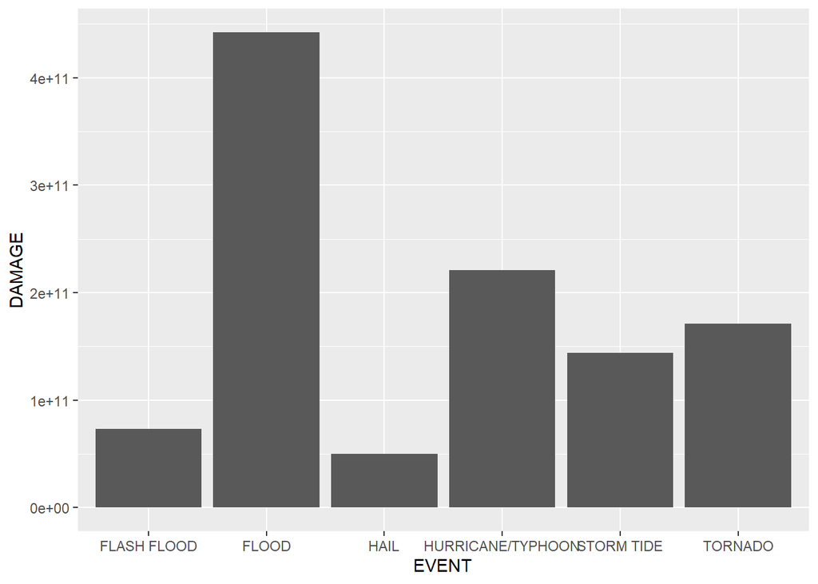

```r
sum_df_economy <- aggregate(DAMAGE ~ EVENT, data = master,  FUN = sum)
sum_df_economy <- sum_df_economy[order(-sum_df_economy$DAMAGE), ]

ggplot(data = head(sum_df_economy), mapping = aes(x = EVENT, y = DAMAGE)) + geom_col()
```

Floods cost more than twice their next competitor, hurricanes.

### (Extra Analysis) On average, what is the most costly storm in terms of health and economic damage?

The questions posed ask which event types have had the greatest impact, which is measured by the sum, but not on average. Let’s explore that instead.

```r
mean_df_economy <- aggregate(DAMAGE ~ EVENT, data = master,  FUN = mean)
mean_df_people <- aggregate(CASUALTIES ~ EVENT, data = master, FUN = mean)
mean_df <- merge(mean_df_economy, mean_df_people)

mean_df[order(-mean_df$DAMAGE), ]
```

|  | EVENT | DAMAGE | CASUALTIES |
| --- | --- | --- | --- |
| 25 | HURRICANE/TYPHOON | 1.973723e+09 | 21.089285714 |
| 37 | STORM TIDE | 3.101196e+08 | 1.000000000 |
| 35 | SEICHE | 1.356629e+08 | 4.416961131 |
| 42 | TROPICAL STORM | 3.362212e+07 | 1.936530324 |
| 43 | TSUNAMI | 2.058838e+07 | 29.714285714 |
| 15 | FLOOD | 1.622232e+07 | 0.627843828 |
| 26 | ICE STORM | 8.454624e+06 | 1.664423077 |
| 9 | DROUGHT | 6.277755e+06 | 0.106998901 |
| 46 | WILDFIRE | 5.492484e+06 | 0.752299203 |
| 40 | TORNADO | 2.821099e+06 | 2.896868304 |

[output cut: 38 more lines]

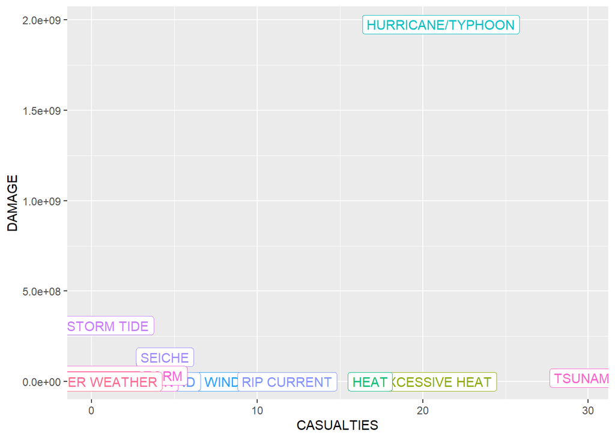

```r
ggplot(data = mean_df, mapping = aes(x = CASUALTIES, y = DAMAGE, color = EVENT)) + geom_label(aes(label = EVENT)) + theme(legend.position = "None")
```

Let’s find out what our two outliers are.

```r
mean_df_economy <- aggregate(DAMAGE ~ EVENT, data = master,  FUN = mean)
mean_df_people <- aggregate(CASUALTIES ~ EVENT, data = master, FUN = mean)
mean_df <- merge(mean_df_economy, mean_df_people)

mean_df[order(-mean_df$DAMAGE), ]
```

|  | EVENT | DAMAGE | CASUALTIES |
| --- | --- | --- | --- |
| 25 | HURRICANE/TYPHOON | 1.973723e+09 | 21.089285714 |
| 37 | STORM TIDE | 3.101196e+08 | 1.000000000 |
| 35 | SEICHE | 1.356629e+08 | 4.416961131 |
| 42 | TROPICAL STORM | 3.362212e+07 | 1.936530324 |
| 43 | TSUNAMI | 2.058838e+07 | 29.714285714 |
| 15 | FLOOD | 1.622232e+07 | 0.627843828 |
| 26 | ICE STORM | 8.454624e+06 | 1.664423077 |
| 9 | DROUGHT | 6.277755e+06 | 0.106998901 |
| 46 | WILDFIRE | 5.492484e+06 | 0.752299203 |
| 40 | TORNADO | 2.821099e+06 | 2.896868304 |

[output cut: 38 more lines]

On average, hurricanes are the worst storms terms of damage, and are close behind tsunamis in terms of casualties.

From this analysis, we can conclude that tornado’s have caused the most overall casualties, floods the most damage, but on average hurricanes are the most devastating storm.